# Data viz

# Scatter plots conditioning in a third variable

There are various ways to plot a third variable in a scatterplot. You could go 3D and in some contexts that may be appropriate. But more often than not it is preferable to use only a two dimensional plot.

If you have a grouping variable you could map it to the colour of the points as one of the aesthetics arguments. Here we return to the Gapminder scatterplot but will add a third variable, that indicates the continent.

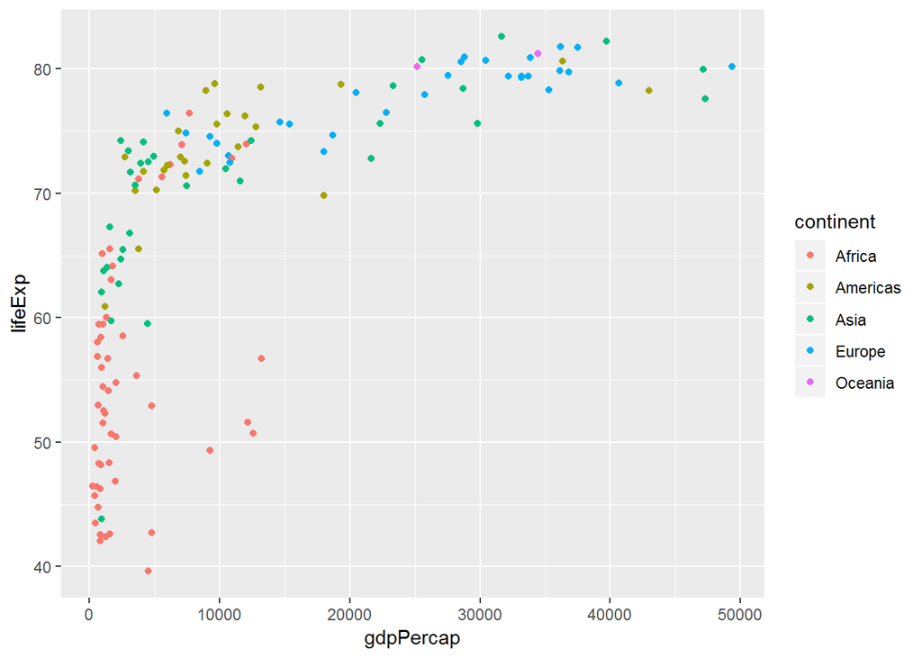

```r
# Scatterplot with two quantitative variables and a grouping variable, we are telling R to tell "continent", as a factor.
ggplot(gapminder_2007, aes(x = gdpPercap, y = lifeExp, colour = continent)) +
  geom_point()
```

We can see distinct differences between continents.

We can also map a quantitative variable to the colour aesthetic. When we do that, instead of different colours for each category we have a gradation in colour from darker to lighter depending on the value of the quantitative variable. Below we display the relationship between life expectancy and gdp conditioning on the size of the population of the country.

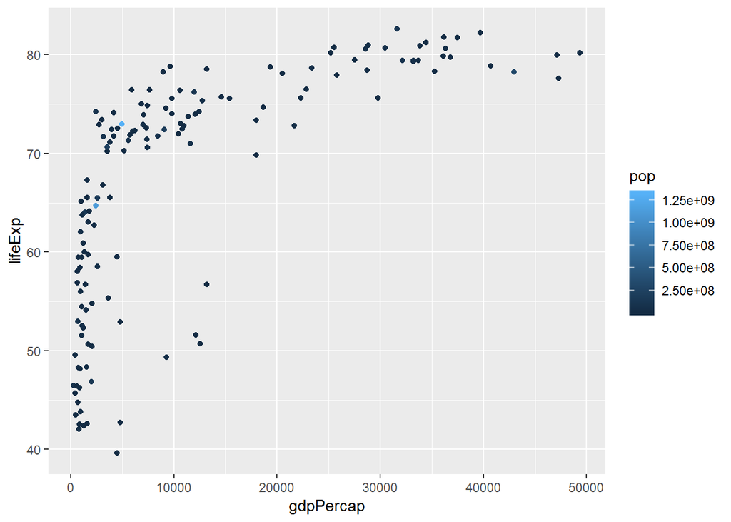

```r
ggplot(gapminder_2007, aes(x = gdpPercap, y = lifeExp, colour = pop)) +
  geom_point()
```

You could map the third variable to a different aesthetic (rather than colour). For example, you could map `pop` to size of the points. This is called a **bubblechart**. The problem with this, however, is that it can make overplotting more acute sometimes.

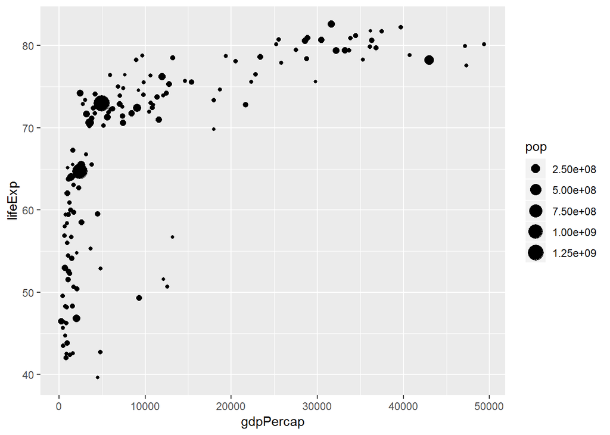

```r
ggplot(gapminder_2007, aes(x = gdpPercap, y = lifeExp, size = pop)) +
  geom_point() # You may want to add alpha for some transparency here.
```

If you have larger samples and the patterns are not clear, conditioning in a third variable can produce hard to read scatterplots (even if you use transparencies and jittering). In these cases, we could try to use facets instead using `facet_wrap()`.

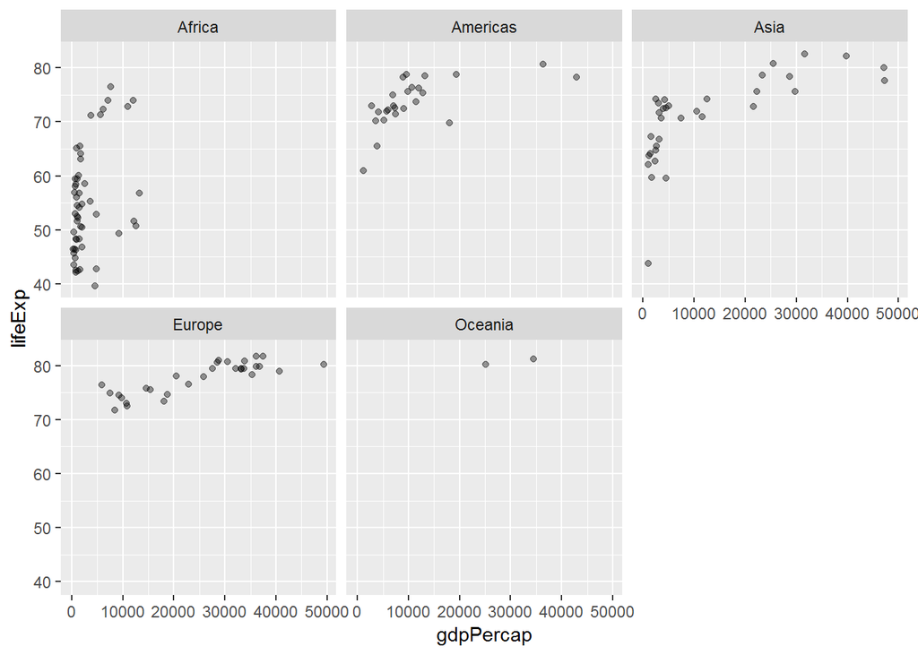

```r
ggplot(gapminder_2007, aes(x = gdpPercap, y = lifeExp)) +
  geom_point(alpha=0.4, position="jitter") +
  facet_wrap( ~ continent)
```

# Titles and legends in ggplot2

We have introduced a number of various graphical tools, but there are many other ways you can further customise your graphs. Here, I am just going to give you some code for how to modify the titles and legends you use. For adding a title for a `ggplot` graph you can use the title option within `labs()`.

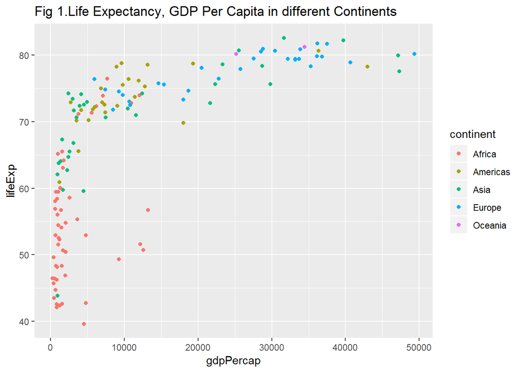

```r
ggplot(gapminder_2007, aes(x = gdpPercap, y = lifeExp, colour = continent)) +
  geom_point() +
  labs(title = "Fig 1.Life Expectancy, GDP Per Capita in different Continents")
```

If you don’t like the default background theme for `ggplot` you can use a theme as discussed at the start, for example with creating a black and white background by adding `theme_bw()` as a layer:

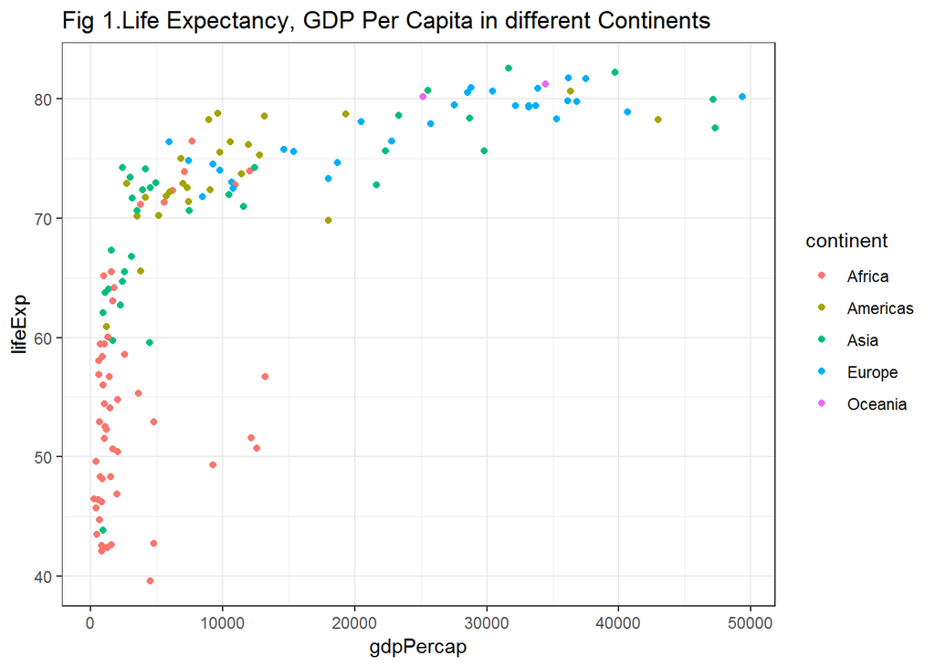

```r
ggplot(gapminder_2007, aes(x = gdpPercap, y = lifeExp, colour = continent)) +
  geom_point() +
  labs(title = "Fig 1.Life Expectancy, GDP Per Capita in different Continents") +
  theme_bw()
```

Using `labs()` you can change the text of axis labels (and the legend title), which may be handy if your variables have cryptic names. Equally you can manually name the labels in a legend. Let’s say we wanted the labels to be all upper case…

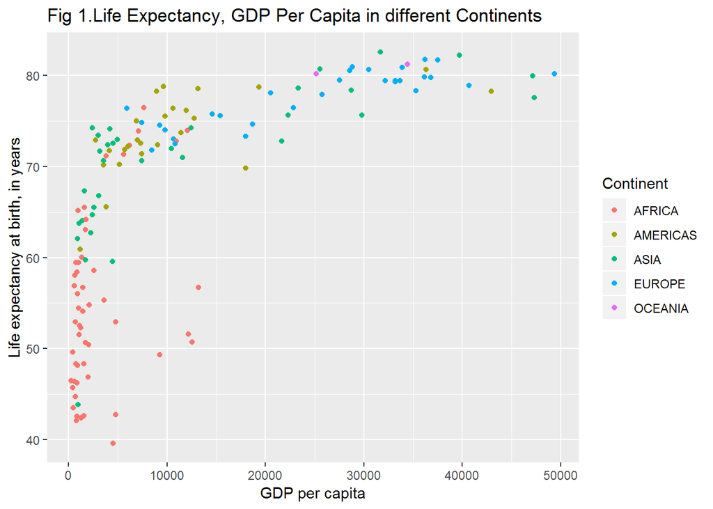

```r
ggplot(gapminder_2007, aes(x = gdpPercap, y = lifeExp, colour = continent)) +
  geom_point() +
  labs(title = "Fig 1.Life Expectancy, GDP Per Capita in different Continents",
       x = "GDP per capita",
       y = "Life expectancy at birth, in years",
       colour = "Continent") +
  scale_colour_discrete(labels = c("AFRICA", "AMERICAS", "ASIA", "EUROPE", "OCEANIA"))
```

# Bar charts

You may be wondering, what about categorical data? So far we have only discussed various visualisations where at least one of your variables is quantitative (continuous). When your variable is categorical you can use bar plots. We map the factor variable in the aesthetics and then use the `geom_bar()` function to ask for a bar chart. The default option for `geom_bar()` is a count, because that’s what most people want barplots for. For this reason, you don’t specify the Y variable, ggplot calculates the counts for you under the hood.

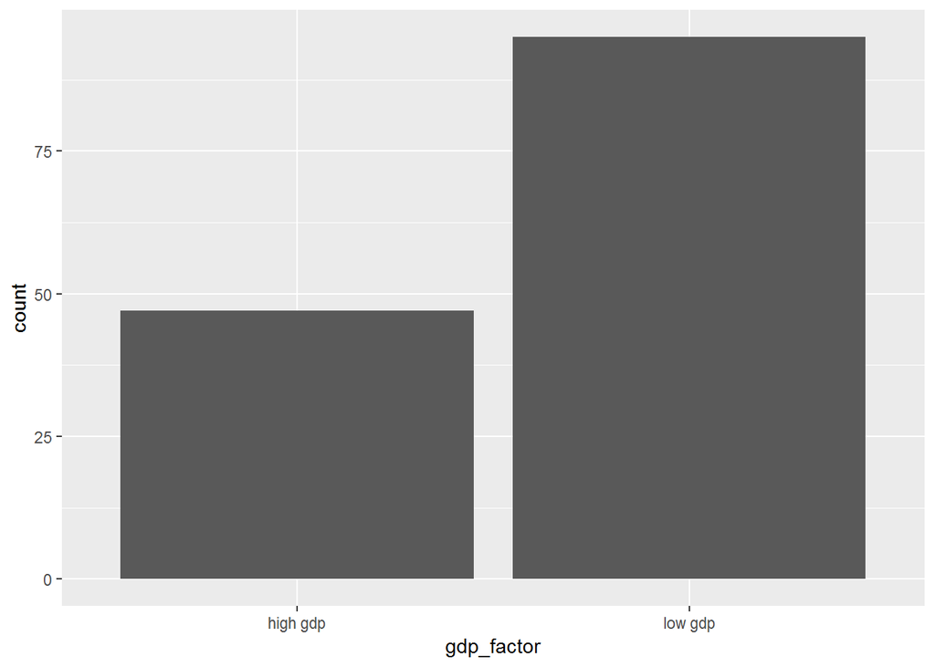

```r
ggplot(gapminder_2007, aes(x=gdp_factor)) +
  geom_bar()
```

Unfortunately, the levels in this factor are ordered by alphabetical order, which is not always what we want. We can modify this by reordering the factors levels first -click [here](http://www.cookbook-r.com/Manipulating_data/Changing_the_order_of_levels_of_a_factor/) for more details. You could do this within the ggplot function (just for the visualisation), but in real life you would want to sort out your factor levels in an appropriate manner more permanently. As discussed earlier, this is the sort of thing you do as part of pre-processing your data. And then plot.

```r
# Print the original order
print(levels(gapminder_2007$gdp_factor))
```

```
[1] "high gdp" "low gdp"
```

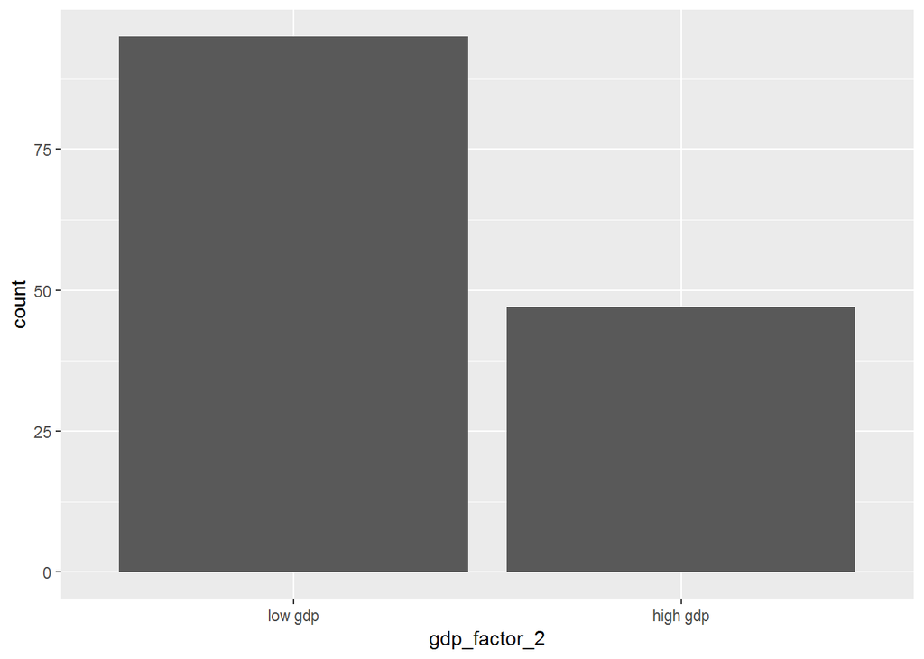

```r
# Reordering the factor levels. Notice that I am creating a new variable. It is often not unwise to do this to avoid messing up your original data.
gapminder_2007$gdp_factor_2 <- factor(gapminder_2007$gdp_factor, levels=c('low gdp', 'high gdp'))
# Plotting the variable again (and subsetting out the NA data)
ggplot(gapminder_2007, aes(x=gdp_factor_2)) +
  geom_bar()
```

We can also map a second variable to the aesthetics, for example, let’s take a look at the low/high gdp variable by continent. For this we produce a **stacked bar chart**.

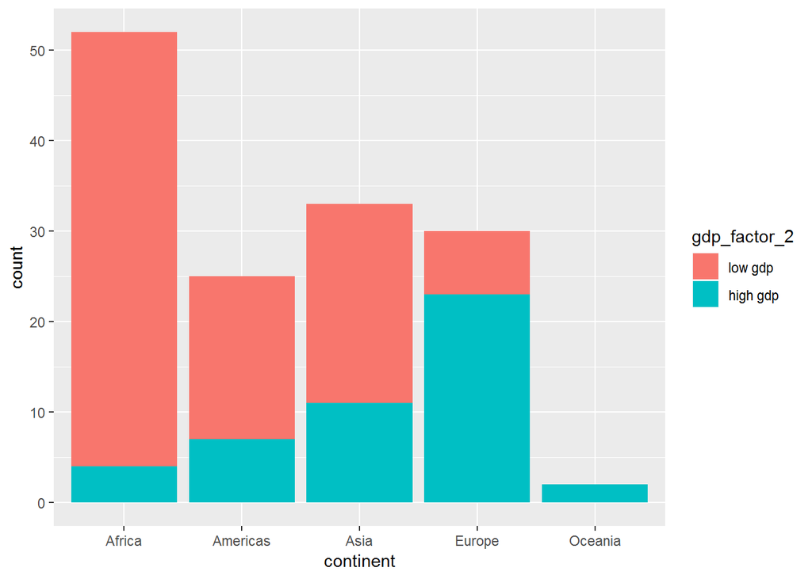

```r
ggplot(gapminder_2007, aes(x=continent, fill = gdp_factor_2)) +
  geom_bar()
```

These sort of stacked bar charts are not terribly helpful if you are interested in understanding the relationship between these two variables. Instead what you may want is a **proportional stacked bar chart**.

First we need to scale the data to 100% within each stack and then plot. The code here is also more complex. Again, I’m not expecting you to fully understand all of it. In your early days of using R, you will find yourself cutting and pasting chunks of code that you will only fully understand with practice.

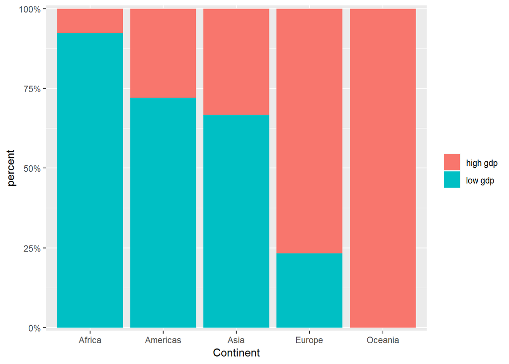

```r
# First we create a subset with the relevant data
.df1 <- data.frame(x = gapminder_2007$continent, z = gapminder_2007$gdp_factor)
# Then we compute the proportions within the stacks
.df1 <- as.data.frame(with(.df1, prop.table(table(x, z), margin = NULL)))
# Finally we plot
stbcf <- ggplot(.df1, aes(x = x, y = Freq, fill = z)) +
  geom_bar(position = "fill", stat = "identity") +
  scale_y_continuous(expand = c(0.01, 0), labels = scales::percent_format()) + # Adapts the scale of the y axis and express the values in percentage terms
  labs(x = "Continent", y = "percent") + # change the labels
  guides(fill = guide_legend(title = NULL)) # This removes the title of the legend (bcsvictim), since the labels of the categories are self-explanatory.
stbcf # autoprint the plot, notice how earlier rather than printing directly I stored the plot in the object with this name (the reason is that I want to use this plot later and don't want to rerun all the code again)
```

```r
rm(.df1) # to remove the data frame we created
```

Sometimes, you may want to flip the axis, so that the bars are displayed horizontally. You can use the `coord_flip()` function for that.

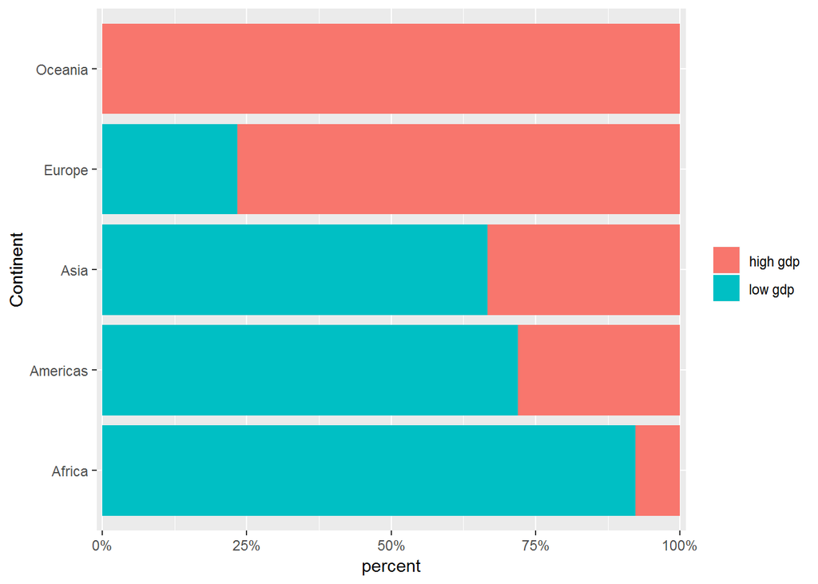

```r
# First we invoke the plot we created and stored earlier and then we add an additional specification with coord_flip()
stbcf + coord_flip()
```

You can also use `coord_flip()` with other `ggplot` plots (e.g., boxplots, bar charts).

A particular type of bar chart is the divergent stacked bar chart, often used to visualise [**Likert scales**](http://en.wikipedia.org/wiki/Likert_scale). You may want to look at some of the options available for it via the [HH package](http://www.jstatsoft.org/v57/i05/paper), the [likert package](http://jason.bryer.org/likert/) or [sjPlot](http://strengejacke.wordpress.com/2013/07/17/plotting-likert-scales-net-stacked-distributions-with-ggplot-rstats/). But we won’t cover them here in detail.

Keep in mind that knowing *how* to get R to produce a particular visualisation is only half the job. The other half is knowing *when* to produce a particular kind of visualisation. [This blog](https://solomonmessing.wordpress.com/2014/10/11/when-to-use-stacked-barcharts/), for example, discusses some of the problems with stacked bar charts and the exceptional circumstances in which you may want to use them.

There are other tools sometimes used for visualising categorical data. Increasingly popular are **mosaic plots**. R is pretty good at doing them. However, we have covered already a lot of ground, plus I have some sympathy for [Stephen Few’s arguments](http://www.perceptualedge.com/articles/visual_business_intelligence/are_mosaic_plots_worthwhile.pdf) against mosaic plots.

What I would use instead are waffle charts. They’re super easy to make with the “waffle” package.

Here is an example using some Brexit data:

```r
library(waffle)
```

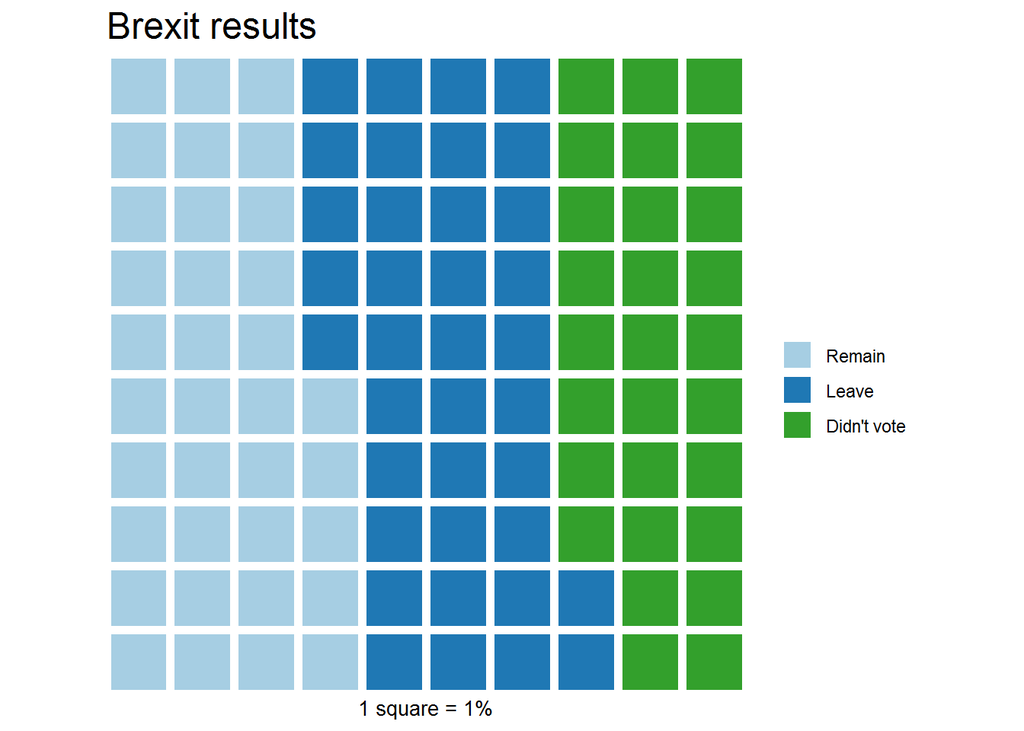

```r
t <- c('Remain' = 35,
       "Leave" = 37,
       "Didn't vote"     = 28)

waffle(t, rows = 10, colors=c("#a6cee3",
                              "#1f78b4",
                              "#33a02c"),
       title="Brexit results",
       xlab="1 square = 1%")
```

You can read more about them [here](https://www.r-bloggers.com/making-waffle-charts-in-r-with-the-new-waffle-package/).

# Interactivity

So we talked about plotly in the presentation. There are excellent resources available online, so I do recommend some further reading.

Other ways of making your charts and overall presentation of information interactive include building [Shiny dashboards](https://rstudio.github.io/shinydashboard/).

Also if you have some spatial data, a nice interactive way to present it is to use [leaflet](https://rstudio.github.io/leaflet/) package.

There are many many ways to visualise and present data available, and this is a really fun thing to play around with, and one of the major strengths of R. I hope that this introduction has been sufficient to get you interested in learning more, and that you can use R to make fun visualisations of your data!

# Resources

[R-for-Criminologists](http://jjmedinaariza.github.io/R-for-Criminologists/) [R4DS](http://r4ds.had.co.nz/data-visualisation.html) [Layered Grammar of Graphics](http://vita.had.co.nz/papers/layered-grammar.pdf) [Rcolourbrewer](http://ggplot2.tidyverse.org/reference/scale_brewer.html)